# Connectivity test new branche

```r
library(itsadug)
library(mgcv)
library(mgcViz)
library(tidyverse)
library(visreg)    # GAM model visualisation
library(permutes)
library(patchwork)

library(afex)       # nouveau package, surveiller les MAJ
library(lme4)
library(RVAideMemoire)
library(LMERConvenienceFunctions)
library(phia)
library(multcomp)
library(lmerTest)
library(emmeans)
library(ggpubr)
library(ggeffects)
library(sjPlot)

library(DHARMa)
```

# Datas

## Load datas

Datas extract from : H2_anat_spike_distance.txt

```r
file_path = "/Volumes/Backup DD/From_BAIE/Julien/Connectivity/Scripts/R/Datas/H2_anat_spike_distance.txt"
datas <- read.table(file_path, header = TRUE)
```

## Preprocessing

We reduce the dimension.  
For instance DC-NC is the same than NC-DC.  
And we remove the AT levels (to ovoid the redundancy in the datas).

```r
datas %>%
  mutate(Organisation = case_when(Organisation == "0" ~ "0",
                                  Organisation == "1" ~ "1"),
         Anatomy = case_when(Anatomy == "NC-NC" ~ "NC-NC",
                             Anatomy == "DC-DC" ~ "DC-DC",
                             Anatomy == "DT-DT" ~ "DT-DT",
                             Anatomy == "OT-OT" ~ "OT-OT",
                             Anatomy == "DC-NC" ~ "NC-DC",
                             Anatomy == "NC-DC" ~ "NC-DC",
                             Anatomy == "DC-DT" ~ "DT-DC",
                             Anatomy == "DT-DC" ~ "DT-DC",
                             Anatomy == "DT-NC" ~ "NC-DT",
                             Anatomy == "NC-DT" ~ "NC-DT",
                             Anatomy == "OT-DT" ~ "DT-OT",
                             Anatomy == "DT-OT" ~ "DT-OT",
                             Anatomy == "OT-NC" ~ "NC-OT",
                             Anatomy == "NC-OT" ~ "NC-OT",
                             Anatomy == "OT-DC" ~ "DC-OT",
                             Anatomy == "DC-OT" ~ "DC-OT"),
         EZ = case_when(EZ == "0" ~ "0",
                        EZ == "1" ~ "1",
                        EZ == "2" ~ "1")) %>%
  drop_na(EZ) %>%
  drop_na(Anatomy) %>%
  mutate(Anatomy = as.factor(Anatomy),
         Organisation = as.factor(Organisation),
         EZ = as.factor(EZ),
         Spasm = as.factor(Spasm),
         Pat_name = as.factor(Pat_name),
         Channels = as.factor(Channels)) -> datas


summary(datas)
```

```
##       Pat_name      Channels       Anatomy    EZ         Spike_rate
##  faissat  :325   f1-k1  :   4   NC-DC  :513   0:1878   Min.   : 0.0000
##  tardy    :300   k1-s1  :   3   DC-OT  :380   1: 259   1st Qu.: 0.4625
##  massenot :253   b2-r1  :   2   DC-DC  :362            Median : 2.8813
##  chelghoum:231   b2-s7  :   2   NC-OT  :288            Mean   : 7.5964
##  vedrine  :210   f1-b2  :   2   NC-NC  :260            3rd Qu.:10.2970
##  mazue    :190   f1-c'1 :   2   OT-OT  :122            Max.   :65.0641
##  (Other)  :628   (Other):2122   (Other):212
##   Spike_count           H2             Distance            Age
##  Min.   :   0.0   Min.   :0.02368   Min.   :  6.164   Min.   : 3.707
##  1st Qu.:   9.0   1st Qu.:0.05237   1st Qu.: 38.314   1st Qu.: 5.756
##  Median :  56.5   Median :0.06730   Median : 55.946   Median :10.849
##  Mean   : 151.5   Mean   :0.07984   Mean   : 57.704   Mean   :14.741
##  3rd Qu.: 206.0   3rd Qu.:0.09053   3rd Qu.: 75.938   3rd Qu.:19.271
##  Max.   :1319.5   Max.   :0.56597   Max.   :124.178   Max.   :37.142
##
##   Toto_Tubers       C_Tubers            EI          Spasm    Organisation
##  Min.   : 3.00   Min.   : 0.000   Min.   :0.00000   0:1175   0:1131
##  1st Qu.:15.00   1st Qu.: 1.000   1st Qu.:0.00229   1: 962   1:1006
##  Median :21.00   Median : 2.000   Median :0.00928
##  Mean   :19.47   Mean   : 3.972   Mean   :0.07273
##  3rd Qu.:24.00   3rd Qu.: 5.000   3rd Qu.:0.04288
##  Max.   :38.00   Max.   :15.000   Max.   :0.69770
##                                   NA's   :40
```

Now there is 9 **Anatomy** levels:  
NC-DT, DT-DC, NC-NC, NC-DC, DC-DC, DT-OT, NC-OT, OT-OT, DC-OT

## How many datas ?

Here we visualize the data from the contingency table or two-way frequency table.  
In this plot, the size represent the proportional value.  
For instance, in the first plot.For DC-OT anatomic level, there is a huge unbalance number of EZ values. With a very few EZ egual 1.  
This means that we can’t analyse the interaction between Anatomic and EZ factors.  
Because there is a very low statistic power (not enough datas within each anatomic levels).

Is not the same for Spasm VS anatomic and Organisation VS Anatomy.

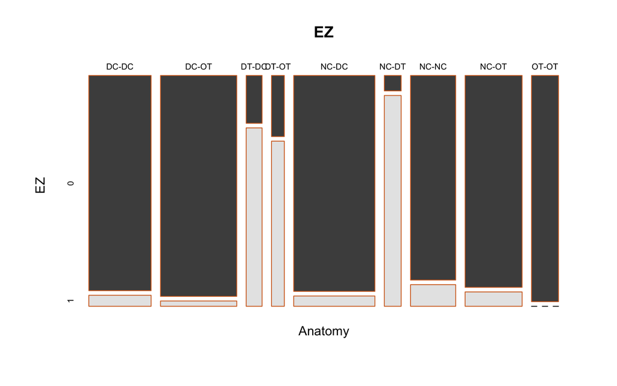

```r
mosaicplot(xtabs(H2~Anatomy+EZ, datas),
           color = TRUE,
           border = "chocolate",
           main = "EZ")
```

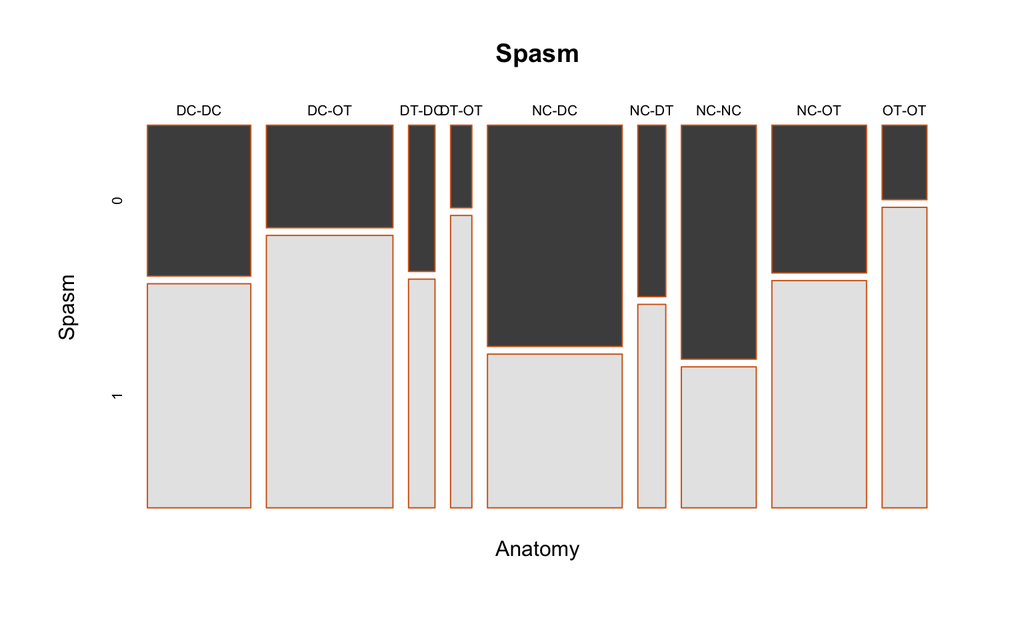

```r
mosaicplot(xtabs(H2~Anatomy+Spasm, datas),
           color = TRUE,
           border = "chocolate",
           main = "Spasm")
```

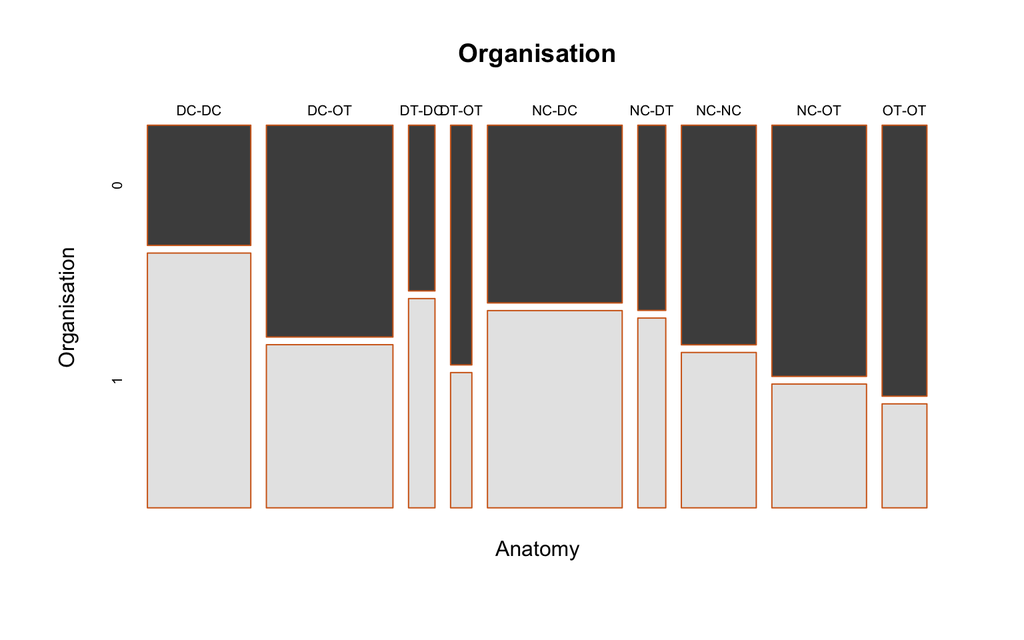

```r
mosaicplot(xtabs(H2~Anatomy+Organisation, datas),
           color = TRUE,
           border = "chocolate",
           main = "Organisation")
```

## Distribution

Then, we explore the nature of your variable of interest: the H2.  
This is the plot of the H2 distribution.  
One color by anatomic level.  
Clearly, it’s not a normal distribution. For several reasons :  
- Datas were borned, there is not 0 value  
- And the shape is not a gaussian with a pic not centered

This means that we can’t use a parametric statistic like anova.  
Typically many people use a log transform. So datas look like a normal distribution.  
But not, with log transform you can get a normal shape distribution but this is artificial, you can’t create the lost information of the left of the distribution. Distribution was cut before 0 and it’s lost for ever.

Later, in our model, we will use a Gamma log description of the error distribution.

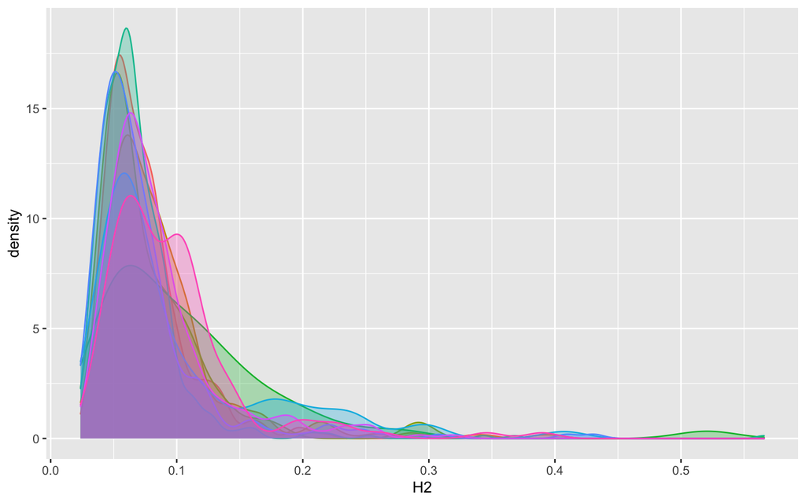

```r
datas %>%
  ggplot(aes(x=H2, fill = Anatomy, color = Anatomy)) +
  geom_density(alpha = 0.3) +
   theme(legend.position = "none")
```

# Statistic

To describe H2 we use a model with :

- Main effect:  
  EZ  
  Spasm  
  C_Tubers  
  Toto_Tuber  
  Organisation  
  Age  
  Distance  
  Anatomy  
  Spike_rate
- Interaction  
  Anatomy*Spasm

We use a GLMM model with Gamma log description of the error distribution.  
The random effect is simpler with only one intercept by patient to take into account variability across patients and non-independence of data within each patients.

For Subject S = 1 : n

We fit 2 models with exactly the same factors but datas change:  
- With the 6 levels of anatomy (interzone)  
- With the grouping of anatomy in 3 levels (intrazone)

## INTRAZONE model

3 Anatomy levels

NC-NC : NC  
DC-DC : DC  
DT-OT & OT-OT : TUBERS

### Model definition

```r
datas %>%
  filter(Anatomy == "NC-NC" | Anatomy == "DC-DC" | Anatomy == "OT-OT" | Anatomy == "DT-OT") %>%
  mutate(Anatomy = case_when(Anatomy == "NC-NC" ~ "NC-NC",
                             Anatomy == "DC-DC" ~ "DC-DC",
                             Anatomy == "DT-OT" ~ "Tuber",
                             Anatomy == "OT-OT" ~ "Tuber"),
         Anatomy = as.factor(Anatomy)) %>%
  data.frame() -> data.intra

model.intra <- mixed(H2 ~ Organisation +
                       scale(Distance) +
                       scale(Spike_rate) +
                       scale(C_Tubers) + scale(Toto_Tubers) + scale(Age) + EZ +
                       Anatomy*Spasm +
                  (1|Pat_name),
                  data = data.intra,
                  method = "LRT",
                  family = Gamma(link = "log"),
                  verbose = FALSE,
                  control = glmerControl(optimizer="bobyqa"))
```

```
## Fitting 11 (g)lmer() models:
## [...........]
```

```r
library(equatiomatic)
equatiomatic::extract_eq(model.intra$full_model, wrap = 2)
```

### Model check quality

**R2**

The marginal 𝑅2 considers only the variance of the fixed effects (without the random effects).  
While the conditional 𝑅2 takes both the fixed and random effects into account.

```r
library(performance)
r2(model.intra$full_model) -> a
```

**Hosmer-Lemeshow Goodness-of-Fit Test**  
Small p-values mean that the model is a poor fit.

```r
performance_hosmer(model.intra$full_model)
```

```
## # Hosmer-Lemeshow Goodness-of-Fit Test
##
##   Chi-squared: 0.123
##            df: 8
##       p-value: 1.000
```

**Overdispersion**

```r
blmeco::dispersion_glmer(model.intra$full_model)
```

```
## [1] 0.3586576
```

**Model performance**  
adjusted ICC (intraclass-correlation coefficient): small is better  
ICC : adjusted ICC (intraclass-correlation coefficient )  
RMSE : root mean squared error  
Sigma : residual standard deviation

```r
performance::model_performance(model.intra$full_model)
```

```
## # Indices of model performance
##
## AIC       |       BIC | R2 (cond.) | R2 (marg.) |   ICC |  RMSE | Sigma
## -----------------------------------------------------------------------
## -3527.123 | -3456.948 |      0.466 |      0.430 | 0.063 | 0.040 | 0.414
```

**Distributions**

```r
check_distribution(model.intra$full_model)
```

```
## # Distribution of Model Family
##
## Predicted Distribution of Residuals
##
##  Distribution Probability
##        normal         75%
##   exponential          9%
##       tweedie          9%
##
## Predicted Distribution of Response
##
##  Distribution Probability
##          beta         41%
##         gamma         25%
##       tweedie         16%
```

As we can see:  
- residuals are normal  
- response gamma is a good aproximation

**Model summary**

```r
jtools::summ(model.intra$full_model)
```

| Observations | 795 |
| --- | --- |
| Dependent variable | H2 |
| Type | Mixed effects generalized linear model |
| Family | Gamma |
| Link | log |

| AIC | -3527.12 |
| --- | --- |
| BIC | -3456.95 |
| Pseudo-R² (fixed effects) | NA |
| Pseudo-R² (total) | NA |

| Fixed Effects | Fixed Effects Est. | Fixed Effects S.E. | Fixed Effects t val. | Fixed Effects p |
| --- | --- | --- | --- | --- |
| (Intercept) | -2.56 | 0.06 | -42.27 | 0.00 |
| Organisation1 | -0.04 | 0.10 | -0.35 | 0.73 |
| scale(Distance) | -0.08 | 0.01 | -6.05 | 0.00 |
| scale(Spike_rate) | 0.09 | 0.02 | 5.04 | 0.00 |
| scale(C_Tubers) | 0.07 | 0.09 | 0.87 | 0.38 |
| scale(Toto_Tubers) | -0.01 | 0.13 | -0.05 | 0.96 |
| scale(Age) | -0.11 | 0.11 | -1.01 | 0.31 |
| EZ1 | -0.03 | 0.03 | -1.32 | 0.19 |
| Anatomy1 | -0.01 | 0.02 | -0.43 | 0.67 |
| Anatomy2 | 0.03 | 0.02 | 1.29 | 0.20 |
| Spasm1 | -0.21 | 0.08 | -2.51 | 0.01 |
| Anatomy1:Spasm1 | 0.02 | 0.02 | 0.84 | 0.40 |
| Anatomy2:Spasm1 | 0.05 | 0.02 | 2.02 | 0.04 |

| Random Effects Group | Random Effects Parameter | Random Effects Std. Dev. |
| --- | --- | --- |
| Pat_name | (Intercept) | 0.11 |
| Residual |  | 0.41 |

| Grouping Variables Group | Grouping Variables # groups | Grouping Variables ICC |
| --- | --- | --- |
| Pat_name | 12 | 0.06 |

Here we find:  
- SE for each fixed effect  
- Random standard deviation (0.11). So ~25% of the residual.

### Analysis of variance

```r
# summ.tab.a <- as.data.frame(anova(model.intra))
# summ.tab.a <- mutate(summ.tab.a, effect = row.names(summ.tab.a))
#
# summ.tab.b <- as.data.frame(anova(model.intra$full_model))
# summ.tab.b <- mutate(summ.tab.b, effect = row.names(summ.tab.b))
#
# left_join(summ.tab.b, summ.tab.a) %>%
#   dplyr::select(effect, Chisq, `Chi Df`, `F value`, `Pr(>Chisq)`)
#
# rm(summ.tab.a, summ.tab.b)

anova(model.intra)
```

```
## Mixed Model Anova Table (Type 3 tests, LRT-method)
##
## Model: H2 ~ Organisation + scale(Distance) + scale(Spike_rate) + scale(C_Tubers) +
## Model:     scale(Toto_Tubers) + scale(Age) + EZ + Anatomy * Spasm +
## Model:     (1 | Pat_name)
## Data: data.intra
## Df full model: 15
##                    Df   Chisq Chi Df Pr(>Chisq)
## Organisation       14  0.1236      1    0.72516
## scale(Distance)    14 35.7060      1  2.295e-09 ***
## scale(Spike_rate)  14 25.7566      1  3.873e-07 ***
## scale(C_Tubers)    14  0.7442      1    0.38833
## scale(Toto_Tubers) 14  0.0023      1    0.96146
## scale(Age)         14  0.9435      1    0.33138
## EZ                 14  1.7679      1    0.18365
## Anatomy            13  1.6841      2    0.43082
## Spasm              14  4.5516      1    0.03289 *
## Anatomy:Spasm      13  7.9093      2    0.01917 *
## ---
## Signif. codes:  0 '***' 0.001 '**' 0.01 '*' 0.05 '.' 0.1 ' ' 1
```

3 significant main effects:  
- Distance  
- Spike-rate  
- Spasm

1 Interaction:  
- Anatomy:Spasm

### Post-Hoc

We explore all significant effects.

#### Anatomy:Spasm

Display of raw and model’s predicted values to better understand how the effects are expressed (qualitativly).  
Predicted values (marginal effects) with confidence interval for specific model terms.

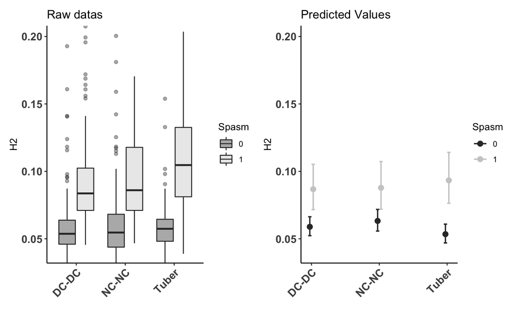

```r
data.intra %>%
  ggplot(aes(x=Anatomy, y=H2, fill = Spasm)) +
  geom_boxplot(alpha = 0.4) +
    coord_cartesian(ylim=c(0.04, 0.20)) +
  scale_fill_grey() +
  theme_classic() +
  theme(legend.position = "right",
        axis.title.x = element_text(size = 14, face = "bold"),
        axis.text.x = element_text(face = "bold", size = 12, angle = 45, hjust = 1),
        axis.text.y = element_text(face = "bold", size = 12, angle = 0, hjust = 1)) +
  labs(x = "",
       y = "H2") +
  ggtitle("Raw datas")-> p1


plot_model(model.intra$full_model,
           type = "pred",
           colors = "gs",
           terms = c("Anatomy", "Spasm")) +
    coord_cartesian(ylim=c(0.04, 0.20)) +
  theme_classic() +
  theme(legend.position = "right",
        axis.title.x = element_text(size = 14, face = "bold"),
        axis.text.x = element_text(face = "bold", size = 12, angle = 45, hjust = 1),
        axis.text.y = element_text(face = "bold", size = 12, angle = 0, hjust = 1)) +
  labs(x = "",
       y = "H2") +
  ggtitle("Predicted Values") -> p2

p1 + p2
```

```r
rm(p1, p2)
```

Here, the statistic values for all comparisons (quantitativly).

```r
emm.intra <- emmeans(model.intra, ~ Spasm | Anatomy, type = "response")

des_cont <- list("Spasm 0-1" = c(1, -1))

contrast(emm.intra, des_cont, adjust = "FDR") %>%
  data.frame()  %>%
  mutate(`(FDR)` = round(p.value,4)) %>%
  dplyr::select(-df, -z.ratio, -ratio, -SE, -p.value) -> cc.01

contrast(emm.intra, des_cont, adjust = "none") %>%
  data.frame() %>%
  dplyr::select(-df, -z.ratio) %>%
  mutate(p.value = round(p.value,4),
         ratio = round(ratio,4),
         SE = round(SE,4)) %>%
  right_join(cc.01) %>%
  mutate(`-` = case_when(`(FDR)` > 0.05 ~ ".",
                        `(FDR)` < 0.05 ~ "*"))
```

```
##    contrast Anatomy  ratio     SE p.value  (FDR) -
## 1 Spasm 0-1   DC-DC 0.6788 0.1176  0.0254 0.0254 *
## 2 Spasm 0-1   NC-NC 0.7201 0.1266  0.0618 0.0618 .
## 3 Spasm 0-1   Tuber 0.5727 0.1016  0.0017 0.0017 *
```

```r
rm(emm.intra, des_cont, cc.01)
```

There is a significant difference between Spasm levels within each Anatomy level except NC-NC.

#### Distance

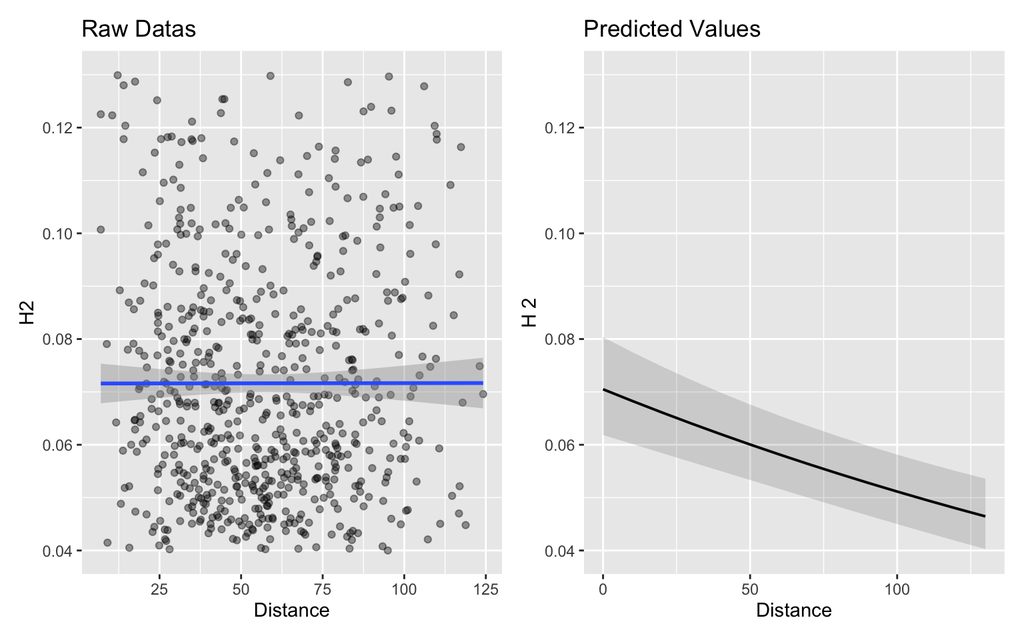

```r
data.intra %>%
  ggplot(aes(x=Distance, y=H2)) +
  geom_point(alpha = 0.4) +
  geom_smooth(method = "lm") +
  ylim(0.04,0.13) +
  ggtitle("Raw Datas") -> p1


plot_model(model.intra$full_model,
           type = "pred",
           terms = c("Distance")) +
  ylim(0.04,0.13) +
  ggtitle("Predicted Values") -> p2

p1 + p2
```

```r
rm(p1, p2)
```

We see a negative effect of the distance on the H2.

#### Spike_rate

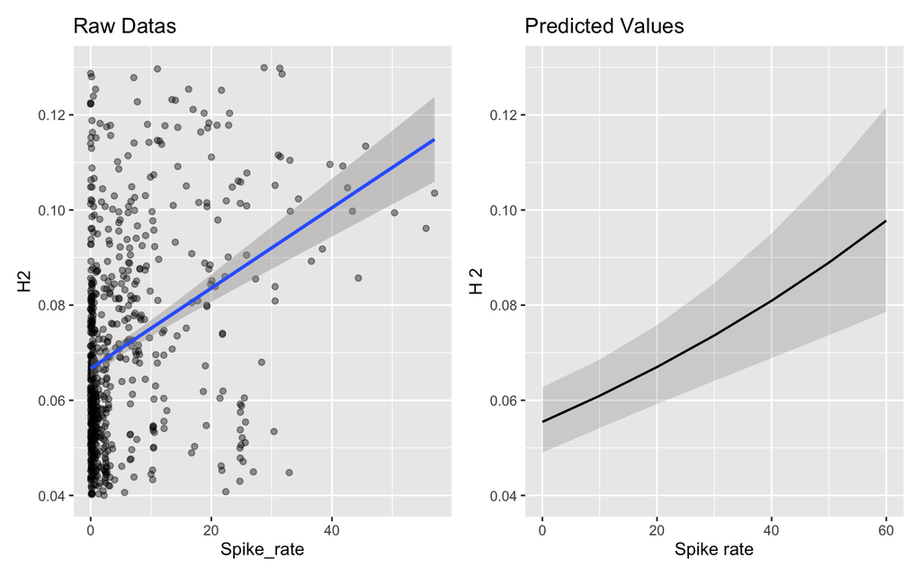

```r
data.intra %>%
  ggplot(aes(x=Spike_rate, y=H2)) +
  geom_point(alpha = 0.4) +
  geom_smooth(method = "lm") +
  ylim(0.04,0.13) +
  ggtitle("Raw Datas") -> p1

plot_model(model.intra$full_model,
           type = "pred",
           terms = c("Spike_rate"))  +
  ylim(0.04,0.13) +
  ggtitle("Predicted Values") -> p2

p1 + p2
```

```r
rm(p1, p2)
```

We see a positive effect of Spike-rate on the H2.  
here we can see the gamma family effect with a curve effect (not a linear effect).

#### Spasm

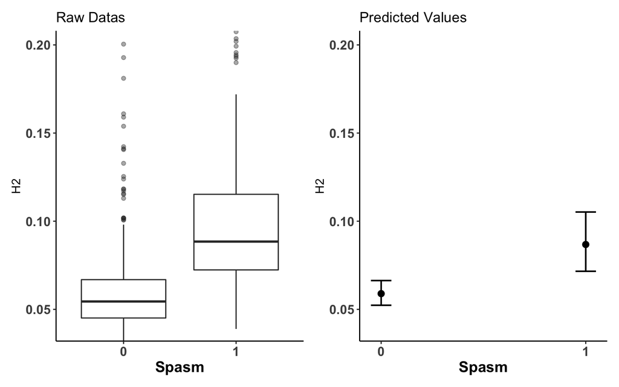

```r
data.intra %>%
  ggplot(aes(x=Spasm, y=H2)) +
  geom_boxplot(alpha = 0.4) +
  theme(axis.text.x = element_text(angle = 90)) +
    coord_cartesian(ylim=c(0.04, 0.20)) +
  scale_fill_grey() +
  theme_classic() +
  theme(legend.position = "right",
        axis.title.x = element_text(size = 14, face = "bold"),
        axis.text.x = element_text(face = "bold", size = 12, angle = 0),
        axis.text.y = element_text(face = "bold", size = 12, angle = 0)) +
  labs(x = "Spasm",
       y = "H2") +
  ggtitle("Raw Datas") -> p1

plot_model(model.intra$full_model,
           type = "pred",
           terms = c("Spasm")) +
    coord_cartesian(ylim=c(0.04, 0.20)) +
  scale_fill_grey() +
  theme_classic() +
  theme(legend.position = "right",
        axis.title.x = element_text(size = 14, face = "bold"),
        axis.text.x = element_text(face = "bold", size = 12, angle = 0),
        axis.text.y = element_text(face = "bold", size = 12, angle = 0)) +
  labs(x = "Spasm",
       y = "H2") +
  ggtitle("Predicted Values") -> p2

p1 + p2
```

```r
rm(p1, p2)
```

We see an H2 higher for the Spasm seizure.

## INTERZONE model

Heres we used 6 Anatomic levels.

DT-OT  
DT-NC  
DT-DC  
OT-NC  
OT-DC  
NC-DC

### Model definition

The same as previous analysis.

```r
data.inter <- filter(datas, Anatomy != "NC-NC" & Anatomy != "DC-DC" & Anatomy != "OT-OT")

model.inter <- mixed(H2 ~ Organisation +
                       scale(Distance) + scale(Spike_rate) +
                       scale(C_Tubers) + scale(Toto_Tubers) + scale(Age) + EZ +
                       Anatomy*Spasm  +
                  (1|Pat_name),
                  data = data.inter,
                  method = "LR",
                  family = Gamma(link = "log"),
                  verbose = FALSE)
```

```
## Fitting 11 (g)lmer() models:
## [...........]
```

### Model check quality

**R2**

The marginal 𝑅2 considers only the variance of the fixed effects (without the random effects).  
While the conditional 𝑅2 takes both the fixed and random effects into account.

```r
library(performance)
r2(model.inter$full_model)
```

```
## # R2 for Mixed Models
##
##   Conditional R2: 0.467
##      Marginal R2: 0.429
```

**Hosmer-Lemeshow Goodness-of-Fit Test**  
Small p-values mean that the model is a poor fit.

```r
performance_hosmer(model.inter$full_model)
```

```
## # Hosmer-Lemeshow Goodness-of-Fit Test
##
##   Chi-squared: 0.130
##            df: 8
##       p-value: 1.000
```

**Overdispersion**

```r
blmeco::dispersion_glmer(model.inter$full_model)
```

```
## [1] 0.353164
```

**Model performance**  
adjusted ICC (intraclass-correlation coefficient): small is better  
ICC : adjusted ICC (intraclass-correlation coefficient )  
RMSE : root mean squared error  
Sigma : residual standard deviation

```r
performance::model_performance(model.inter$full_model)
```

```
## # Indices of model performance
##
## AIC       |       BIC | R2 (cond.) | R2 (marg.) |   ICC |  RMSE | Sigma
## -----------------------------------------------------------------------
## -6228.257 | -6118.234 |      0.467 |      0.429 | 0.066 | 0.040 | 0.416
```

**Distributions**

```r
check_distribution(model.inter$full_model)
```

```
## # Distribution of Model Family
##
## Predicted Distribution of Residuals
##
##  Distribution Probability
##        normal         75%
##   exponential          9%
##       tweedie          9%
##
## Predicted Distribution of Response
##
##  Distribution Probability
##          beta         38%
##         gamma         28%
##       tweedie         16%
```

As we can see:  
- residuals are normal  
- response gamma is a good aproximation

**Model summary**

```r
jtools::summ(model.inter$full_model)
```

| Observations | 1393 |
| --- | --- |
| Dependent variable | H2 |
| Type | Mixed effects generalized linear model |
| Family | Gamma |
| Link | log |

| AIC | -6228.26 |
| --- | --- |
| BIC | -6118.23 |
| Pseudo-R² (fixed effects) | NA |
| Pseudo-R² (total) | NA |

| Fixed Effects | Fixed Effects Est. | Fixed Effects S.E. | Fixed Effects t val. | Fixed Effects p |
| --- | --- | --- | --- | --- |
| (Intercept) | -2.55 | 0.07 | -36.59 | 0.00 |
| Organisation1 | -0.04 | 0.11 | -0.34 | 0.73 |
| scale(Distance) | -0.08 | 0.01 | -8.33 | 0.00 |
| scale(Spike_rate) | 0.11 | 0.01 | 8.24 | 0.00 |
| scale(C_Tubers) | 0.13 | 0.09 | 1.35 | 0.18 |
| scale(Toto_Tubers) | -0.08 | 0.14 | -0.57 | 0.57 |
| scale(Age) | -0.05 | 0.11 | -0.47 | 0.64 |
| EZ1 | 0.03 | 0.02 | 1.45 | 0.15 |
| AnatomyDT-DC | -0.15 | 0.06 | -2.57 | 0.01 |
| AnatomyDT-OT | 0.01 | 0.07 | 0.14 | 0.89 |
| AnatomyNC-DC | -0.11 | 0.03 | -4.34 | 0.00 |
| AnatomyNC-DT | 0.03 | 0.07 | 0.46 | 0.65 |
| AnatomyNC-OT | -0.02 | 0.03 | -0.68 | 0.50 |
| Spasm1 | -0.24 | 0.10 | -2.53 | 0.01 |
| AnatomyDT-DC:Spasm1 | -0.02 | 0.04 | -0.46 | 0.65 |
| AnatomyDT-OT:Spasm1 | -0.07 | 0.05 | -1.38 | 0.17 |
| AnatomyNC-DC:Spasm1 | 0.10 | 0.03 | 3.73 | 0.00 |
| AnatomyNC-DT:Spasm1 | -0.05 | 0.05 | -1.05 | 0.29 |
| AnatomyNC-OT:Spasm1 | 0.11 | 0.03 | 3.91 | 0.00 |

| Random Effects Group | Random Effects Parameter | Random Effects Std. Dev. |
| --- | --- | --- |
| Pat_name | (Intercept) | 0.11 |
| Residual |  | 0.42 |

| Grouping Variables Group | Grouping Variables # groups | Grouping Variables ICC |
| --- | --- | --- |
| Pat_name | 12 | 0.07 |

Here we find:  
- SE for each fixed effect  
- Random standard deviation (0.11). So ~25% of the residual.

### Analysis of variance

```r
summ.tab.a <- as.data.frame(anova(model.inter))
summ.tab.a <- mutate(summ.tab.a, effect = row.names(summ.tab.a))

summ.tab.b <- as.data.frame(Anova(model.inter$full_model, type = "III"))
summ.tab.b <- mutate(summ.tab.b, effect = row.names(summ.tab.b))

left_join(summ.tab.b, summ.tab.a) %>%
  dplyr::select(effect, Chisq, `Df`, `Pr(>Chisq)`)
```

```
##                effect        Chisq Df    Pr(>Chisq)
## 1         (Intercept) 1338.7709455  1 4.244691e-293
## 2        Organisation    0.1163568  1  7.330199e-01
## 3     scale(Distance)   69.3150977  1  8.392470e-17
## 4   scale(Spike_rate)   67.8681508  1  1.748020e-16
## 5     scale(C_Tubers)    1.8096885  1  1.785456e-01
## 6  scale(Toto_Tubers)    0.3280526  1  5.668081e-01
## 7          scale(Age)    0.2201976  1  6.388894e-01
## 8                  EZ    2.0890445  1  1.483588e-01
## 9             Anatomy   34.0875978  5  2.287280e-06
## 10              Spasm    6.4227369  1  1.126684e-02
## 11      Anatomy:Spasm   37.6297226  5  4.477835e-07
```

```r
rm(summ.tab.a, summ.tab.b)
```

```r
Anova(model.inter$full_model, type = "III")
```

```
## Analysis of Deviance Table (Type III Wald chisquare tests)
##
## Response: H2
##                        Chisq Df Pr(>Chisq)
## (Intercept)        1338.7709  1  < 2.2e-16 ***
## Organisation          0.1164  1    0.73302
## scale(Distance)      69.3151  1  < 2.2e-16 ***
## scale(Spike_rate)    67.8682  1  < 2.2e-16 ***
## scale(C_Tubers)       1.8097  1    0.17855
## scale(Toto_Tubers)    0.3281  1    0.56681
## scale(Age)            0.2202  1    0.63889
## EZ                    2.0890  1    0.14836
## Anatomy              34.0876  5  2.287e-06 ***
## Spasm                 6.4227  1    0.01127 *
## Anatomy:Spasm        37.6297  5  4.478e-07 ***
## ---
## Signif. codes:  0 '***' 0.001 '**' 0.01 '*' 0.05 '.' 0.1 ' ' 1
```

1 Interaction:  
- Anatomy:Spasm

### Post-Hoc

#### Anatomy:Spasm

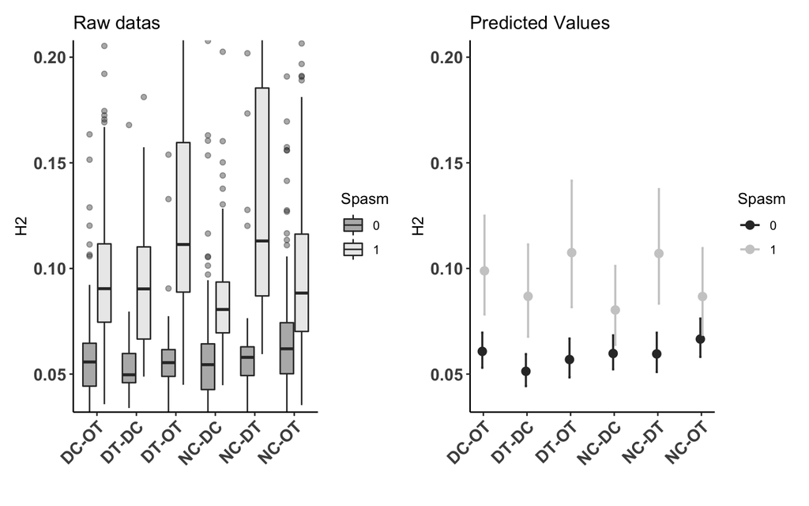

```r
data.inter %>%
  ggplot(aes(x=Anatomy, y=H2, fill = Spasm)) +
  geom_boxplot(alpha = 0.4) +
    coord_cartesian(ylim=c(0.04, 0.20)) +
  scale_fill_grey() +
  theme_classic() +
  theme(legend.position = "right",
        axis.title.x = element_text(size = 14, face = "bold"),
        axis.text.x = element_text(face = "bold", size = 12, angle = 45, hjust = 1),
        axis.text.y = element_text(face = "bold", size = 12, angle = 0, hjust = 1)) +
  labs(x = "",
       y = "H2") +
  ggtitle("Raw datas")-> p1


plot_model(model.inter$full_model,
           type = "pred",
           colors = "gs",
           terms = c("Anatomy", "Spasm")) +
    coord_cartesian(ylim=c(0.04, 0.20)) +
  theme_classic() +
  theme(legend.position = "right",
        axis.title.x = element_text(size = 14, face = "bold"),
        axis.text.x = element_text(face = "bold", size = 12, angle = 45, hjust = 1),
        axis.text.y = element_text(face = "bold", size = 12, angle = 0, hjust = 1)) +
  labs(x = "",
       y = "H2") +
  ggtitle("Predicted Values") -> p2

p1 + p2
```

```r
rm(p1, p2)
```

```r
emm.inter <- emmeans(model.inter, ~ Spasm | Anatomy, type = "response")

des_cont <- list("Spasm 0-1" = c(1, -1))

contrast(emm.inter, des_cont, adjust = "FDR") %>%
  data.frame()  %>%
  mutate(`(FDR)` = round(p.value,4)) %>%
  dplyr::select(-df, -z.ratio, -ratio, -SE, -p.value) -> cc.01

contrast(emm.inter, des_cont, adjust = "none") %>%
  data.frame() %>%
  dplyr::select(-df, -z.ratio) %>%
  mutate(p.value = round(p.value,4),
         ratio = round(ratio,4),
         SE = round(SE,4)) %>%
  right_join(cc.01) %>%
  mutate(`-` = case_when(`(FDR)` > 0.05 ~ ".",
                        `(FDR)` < 0.05 ~ "*"))
```

```
##    contrast Anatomy  ratio     SE p.value  (FDR) -
## 1 Spasm 0-1   DC-OT 0.6144 0.1181  0.0113 0.0113 *
## 2 Spasm 0-1   DT-DC 0.5911 0.1201  0.0097 0.0097 *
## 3 Spasm 0-1   DT-OT 0.5292 0.1133  0.0030 0.0030 *
## 4 Spasm 0-1   NC-DC 0.7438 0.1425  0.1224 0.1224 .
## 5 Spasm 0-1   NC-DT 0.5561 0.1151  0.0046 0.0046 *
## 6 Spasm 0-1   NC-OT 0.7678 0.1483  0.1714 0.1714 .
```

```r
rm(emm.intra, des_cont, cc.01)
```

There is a significant difference between Spasm levels within each Anatomy level except for NC-DC and NC-OT.

#### Distance

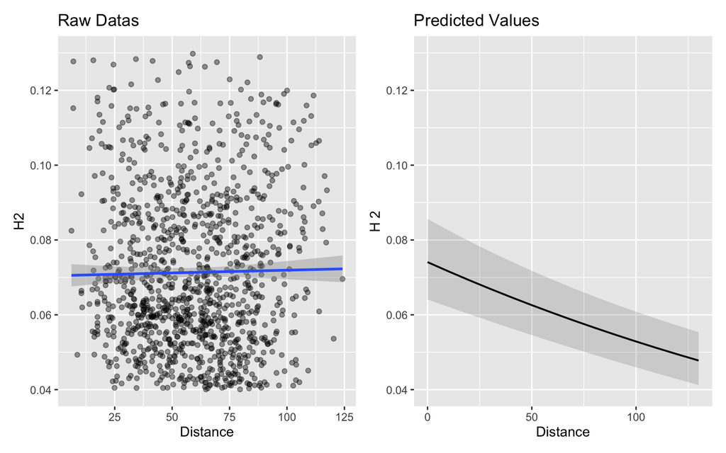

```r
data.inter %>%
  ggplot(aes(x=Distance, y=H2)) +
  geom_point(alpha = 0.4) +
  geom_smooth(method = "lm") +
  ylim(0.04,0.13) +
  ggtitle("Raw Datas") -> p1


plot_model(model.inter$full_model,
           type = "pred",
           terms = c("Distance")) +
  ylim(0.04,0.13) +
  ggtitle("Predicted Values") -> p2

p1 + p2
```

```r
rm(p1, p2)
```

We see a negative effect of the distance on the H2.

#### Spike_rate

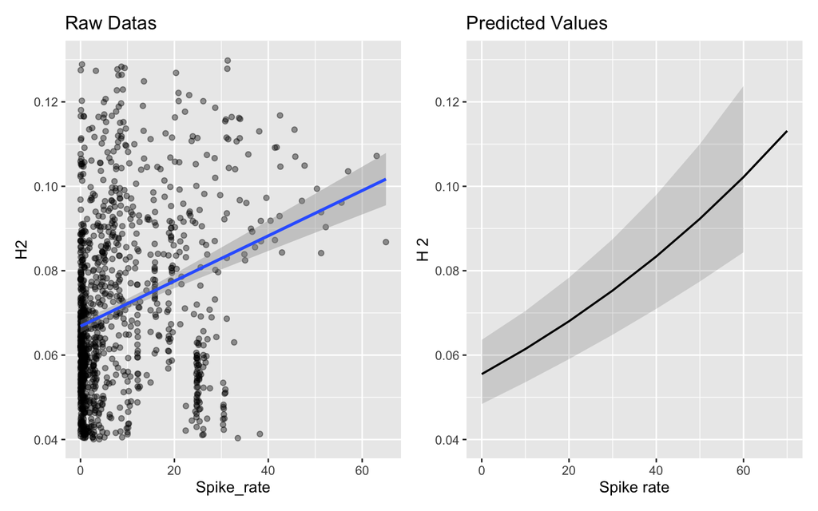

```r
data.inter %>%
  ggplot(aes(x=Spike_rate, y=H2)) +
  geom_point(alpha = 0.4) +
  geom_smooth(method = "lm") +
  ylim(0.04,0.13) +
  ggtitle("Raw Datas") -> p1

plot_model(model.inter$full_model,
           type = "pred",
           terms = c("Spike_rate"))  +
  ylim(0.04,0.13) +
  ggtitle("Predicted Values") -> p2

p1 + p2
```

```r
rm(p1, p2)
```

We see a positive effect of the Spike-rate on the H2.

#### Spasm

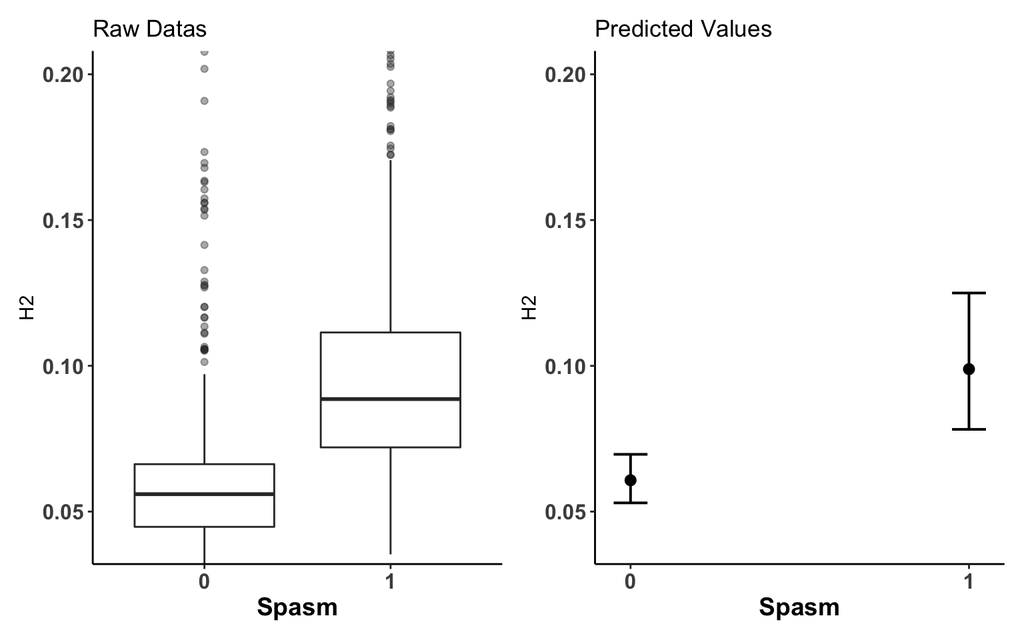

```r
data.inter %>%
  ggplot(aes(x=Spasm, y=H2)) +
  geom_boxplot(alpha = 0.4) +
  theme(axis.text.x = element_text(angle = 90)) +
    coord_cartesian(ylim=c(0.04, 0.20)) +
  scale_fill_grey() +
  theme_classic() +
  theme(legend.position = "right",
        axis.title.x = element_text(size = 14, face = "bold"),
        axis.text.x = element_text(face = "bold", size = 12, angle = 0),
        axis.text.y = element_text(face = "bold", size = 12, angle = 0)) +
  labs(x = "Spasm",
       y = "H2") +
  ggtitle("Raw Datas") -> p1

plot_model(model.inter$full_model,
           type = "pred",
           terms = c("Spasm")) +
    coord_cartesian(ylim=c(0.04, 0.20)) +
  scale_fill_grey() +
  theme_classic() +
  theme(legend.position = "right",
        axis.title.x = element_text(size = 14, face = "bold"),
        axis.text.x = element_text(face = "bold", size = 12, angle = 0),
        axis.text.y = element_text(face = "bold", size = 12, angle = 0)) +
  labs(x = "Spasm",
       y = "H2") +
  ggtitle("Predicted Values") -> p2

p1 + p2
```

```r
rm(p1, p2)
```

We see an H2 higher for the Spasm seizure.

#### Anatomy

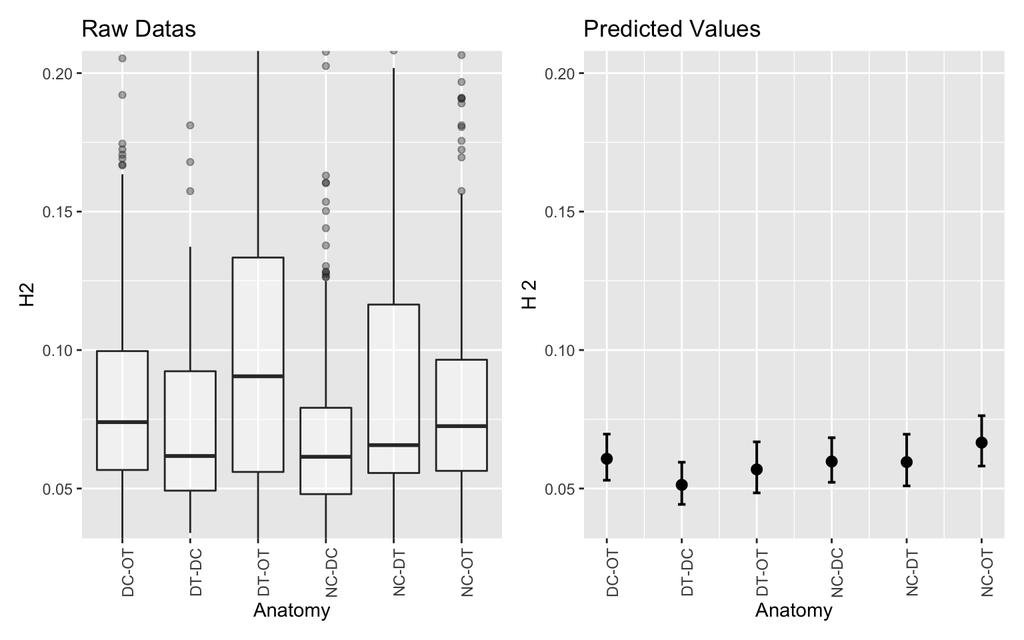

```r
data.inter %>%
  ggplot(aes(x=Anatomy, y=H2)) +
  geom_boxplot(alpha = 0.4) +
  theme(axis.text.x = element_text(angle = 90)) +
    coord_cartesian(ylim=c(0.04, 0.20)) +
  ggtitle("Raw Datas") -> p1

plot_model(model.inter$full_model,
           type = "pred",
           terms = c("Anatomy")) +
    coord_cartesian(ylim=c(0.04, 0.20)) +
  theme(axis.text.x = element_text(angle = 90)) +
  ggtitle("Predicted Values") -> p2

p1 + p2
```

```r
rm(p1, p2)
```

```r
emm.inter <- emmeans(model.inter, ~ Anatomy, type = "response")

des_cont <- list("DC-OT VS DT-DC" = c(1, -1,  0,  0, 0, 0),
                 "DC-OT VS DT-OT" = c(1,  0, -1,  0, 0, 0),
                 "DC-OT VS NC-DC" = c(1,  0,  0, -1, 0, 0),
                 "DC-OT VS NC-DT" = c(1,  0,  0, 0, -1, 0),
                 "DC-OT VS NC-OT" = c(1,  0,  0, 0, 0, -1),
                 "DT-DC VS DT-OT" = c(0,  1, -1, 0, 0, 0),
                 "DT-DC VS NC-DC" = c(0,  1,  0, -1, 0, 0),
                 "DT-DC VS NC-DT" = c(0,  1,  0, 0, -1, 0),
                 "DT-DC VS NC-OT" = c(0,  1,  0, 0, 0, -1),
                 "DT-OT VS NC-DC" = c(0,  0,  1, -1, 0, 0),
                 "DT-OT VS NC-DT" = c(0,  0,  1, 0, -1, 0),
                 "DT-OT VS NC-OT" = c(0,  0,  1, 0, 0, -1),
                 "NC-DC VS NC-DT" = c(0,  0,  0, 1, -1, 0),
                 "NC-DC VS NC-OT" = c(0,  0,  0, 1, 0, -1),
                 "NC-DT VS NC-OT" = c(0,  0,  0, 0, 1, -1)
                 )

contrast(emm.inter, des_cont, adjust = "FDR") %>%
  data.frame()  %>%
  mutate(`(FDR)` = round(p.value,4)) %>%
  dplyr::select(-df, -z.ratio, -ratio, -SE, -p.value) -> cc.01

contrast(emm.inter, des_cont, adjust = "none") %>%
  data.frame() %>%
  dplyr::select(-df, -z.ratio) %>%
  mutate(p.value = round(p.value,4),
         ratio = round(ratio,4),
         SE = round(SE,4)) %>%
  right_join(cc.01) %>%
  mutate(`-` = case_when(`(FDR)` > 0.05 ~ ".",
                        `(FDR)` < 0.05 ~ "*"))
```

```
##          contrast  ratio     SE p.value  (FDR) -
## 1  DC-OT VS DT-DC 1.1610 0.0674  0.0101 0.0345 *
## 2  DC-OT VS DT-OT 0.9908 0.0660  0.8903 0.8903 .
## 3  DC-OT VS NC-DC 1.1184 0.0288  0.0000 0.0002 *
## 4  DC-OT VS NC-DT 0.9704 0.0636  0.6472 0.7600 .
## 5  DC-OT VS NC-OT 1.0198 0.0294  0.4951 0.6840 .
## 6  DT-DC VS DT-OT 0.8534 0.0535  0.0115 0.0345 *
## 7  DT-DC VS NC-DC 0.9633 0.0536  0.5016 0.6840 .
## 8  DT-DC VS NC-DT 0.8359 0.0481  0.0018 0.0092 *
## 9  DT-DC VS NC-OT 0.8784 0.0503  0.0235 0.0503 .
## 10 DT-OT VS NC-DC 1.1287 0.0730  0.0612 0.1147 .
## 11 DT-OT VS NC-DT 0.9794 0.0652  0.7544 0.8082 .
## 12 DT-OT VS NC-OT 1.0293 0.0672  0.6586 0.7600 .
## 13 NC-DC VS NC-DT 0.8677 0.0542  0.0231 0.0503 .
## 14 NC-DC VS NC-OT 0.9119 0.0248  0.0007 0.0051 *
## 15 NC-DT VS NC-OT 1.0509 0.0665  0.4324 0.6840 .
```